# Chapter 5

# Dimentionality reduction techniques

Data wrangling exercises are done in the corresponding R script.

## Analysis exercises

### Graphic overview of the data

Firstly, the data is read from csv-file:

```r
library(GGally)
human_data <- read.csv('data/human1.csv',row.names = 1)
summary(human_data)
```

```
##    edu_ratio        lab_ratio         edu_exp         life_exp          gni
##  Min.   :0.1717   Min.   :0.1857   Min.   : 5.40   Min.   :49.00   Min.   :   581
##  1st Qu.:0.7264   1st Qu.:0.5984   1st Qu.:11.25   1st Qu.:66.30   1st Qu.:  4198
##  Median :0.9375   Median :0.7535   Median :13.50   Median :74.20   Median : 12040
##  Mean   :0.8529   Mean   :0.7074   Mean   :13.18   Mean   :71.65   Mean   : 17628
##  3rd Qu.:0.9968   3rd Qu.:0.8535   3rd Qu.:15.20   3rd Qu.:77.25   3rd Qu.: 24512
##  Max.   :1.4967   Max.   :1.0380   Max.   :20.20   Max.   :83.50   Max.   :123124
##     mat_mor         adol_birth       parl_perc
##  Min.   :   1.0   Min.   :  0.60   Min.   : 0.00
##  1st Qu.:  11.5   1st Qu.: 12.65   1st Qu.:12.40
##  Median :  49.0   Median : 33.60   Median :19.30
##  Mean   : 149.1   Mean   : 47.16   Mean   :20.91
##  3rd Qu.: 190.0   3rd Qu.: 71.95   3rd Qu.:27.95
##  Max.   :1100.0   Max.   :204.80   Max.   :57.50
```

[output not shown]

[output cut: 9 more lines]

[output not shown]

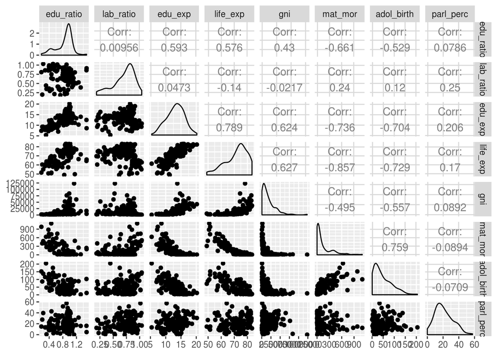

```r
ggpairs(human_data)
```

The plot above visualizes the *human_data* variables.

The plot below shows the correlations between variables:

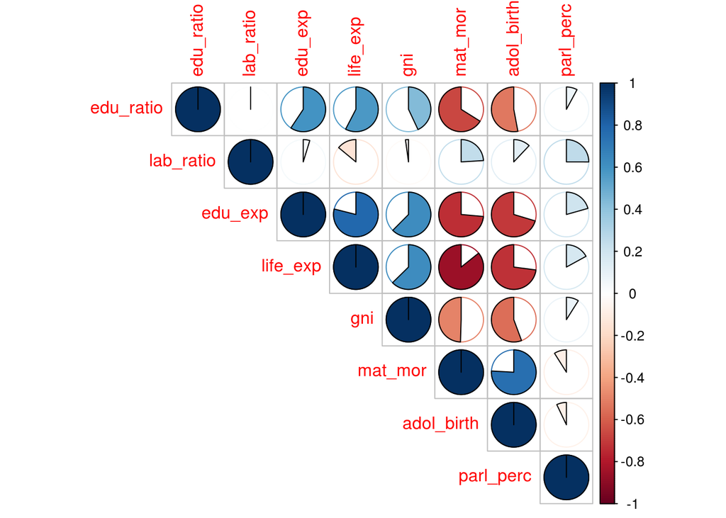

```r
cor(human_data) %>%
corrplot::corrplot(method='pie', type='upper')
```

Let’s take a look at the *edu_exp* (expected years of schooling). It highly positively correlates with *life_exp* (life expectancy at birth) and with *gni* (Gross National Income per capita). On the other hand, it is highly negatively correlates with *mat_mor* (maternal mortality ratio) and *adol_birth* (adolescent birth rate) which actually makes sense: the higher the quality of life in the country, the better the level of medical care in it. Maternal mortality also highly correlates with the adolescent birth rate.

However, *parl_perc* (percentage of female representatives in parliament) doesn’t seem to correlate highly with anything. It correlates slightly with *lab_ratio* (labour ratio) and *edu_exp*, but not so much.

### PCA on not standardized data

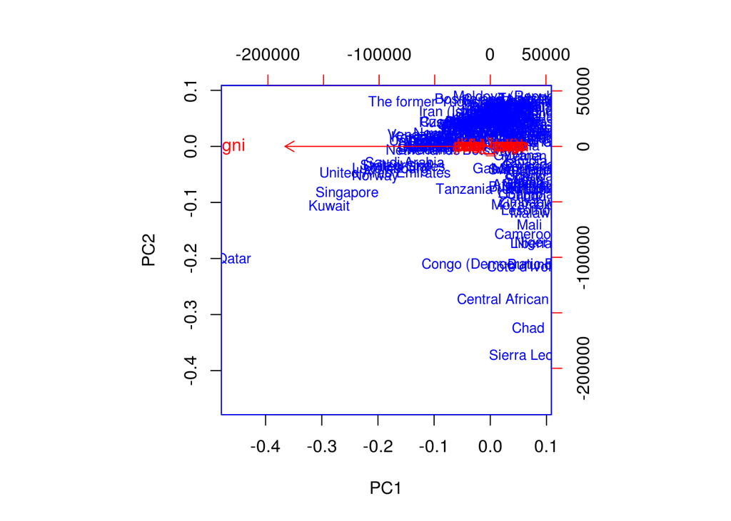

```r
pca_human <- prcomp(human_data)
biplot(pca_human, choices = 1:2, cex=c(0.8,1), col=c("blue", "red"))
```

### PCA on standardized data

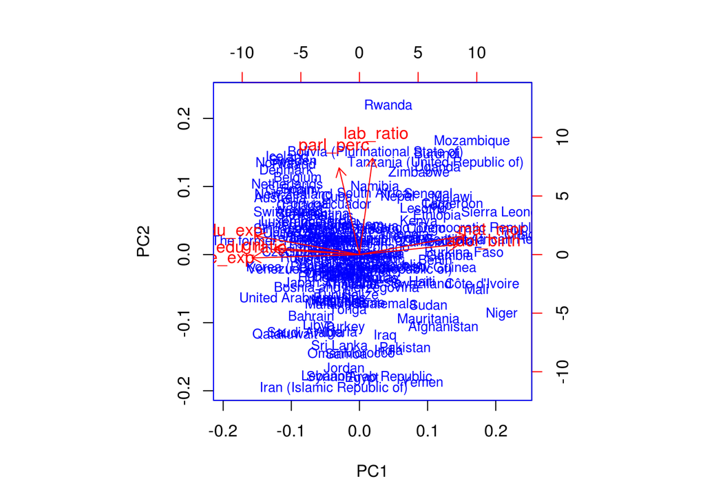

```r
human_std <- scale(human_data)
pca_human <- prcomp(human_std)
biplot(pca_human, choices = 1:2, cex=c(0.8,1), col=c("blue", "red"))
```

The expected years of education, life expectancy, Gross National Income and the ratio of females to males having at least secondary education correlate with each other. The lower the value of PC1, the higher the values of these variables.

On the other hand, maternal mortality correlates with the adolescent birth rate (as it was shown in the correlation plot). The higher the value of PC1, the higher the values of these variables.

There is also a correlation between percentage of female representatives in parliament and the ratio of females to males in the labour force, though it is lower than aforementioned correlations.

### Dealing with the FactoMineR package

```r
library(FactoMineR)
library(tidyr)
data(tea)
str(tea)
```

```
## 'data.frame':    300 obs. of  36 variables:
##  $ breakfast       : Factor w/ 2 levels "breakfast","Not.breakfast": 1 1 2 2 1 2 1 2 1 1 ...
##  $ tea.time        : Factor w/ 2 levels "Not.tea time",..: 1 1 2 1 1 1 2 2 2 1 ...
##  $ evening         : Factor w/ 2 levels "evening","Not.evening": 2 2 1 2 1 2 2 1 2 1 ...
##  $ lunch           : Factor w/ 2 levels "lunch","Not.lunch": 2 2 2 2 2 2 2 2 2 2 ...
##  $ dinner          : Factor w/ 2 levels "dinner","Not.dinner": 2 2 1 1 2 1 2 2 2 2 ...
##  $ always          : Factor w/ 2 levels "always","Not.always": 2 2 2 2 1 2 2 2 2 2 ...
##  $ home            : Factor w/ 2 levels "home","Not.home": 1 1 1 1 1 1 1 1 1 1 ...
##  $ work            : Factor w/ 2 levels "Not.work","work": 1 1 2 1 1 1 1 1 1 1 ...
##  $ tearoom         : Factor w/ 2 levels "Not.tearoom",..: 1 1 1 1 1 1 1 1 1 2 ...
##  $ friends         : Factor w/ 2 levels "friends","Not.friends": 2 2 1 2 2 2 1 2 2 2 ...
##  $ resto           : Factor w/ 2 levels "Not.resto","resto": 1 1 2 1 1 1 1 1 1 1 ...
##  $ pub             : Factor w/ 2 levels "Not.pub","pub": 1 1 1 1 1 1 1 1 1 1 ...
##  $ Tea             : Factor w/ 3 levels "black","Earl Grey",..: 1 1 2 2 2 2 2 1 2 1 ...
##  $ How             : Factor w/ 4 levels "alone","lemon",..: 1 3 1 1 1 1 1 3 3 1 ...
```

[output cut: 22 more lines]

```r
dim(tea)
```

```
## [1] 300  36
```

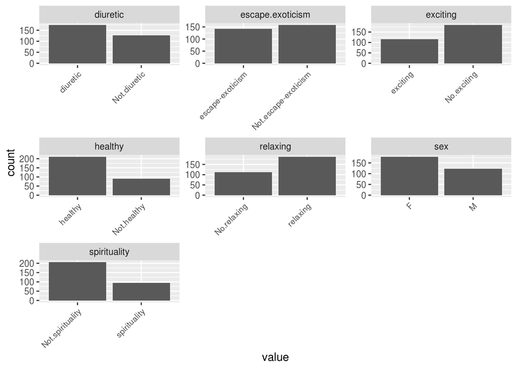

```r
reasons <- c('sex','spirituality', 'healthy','diuretic','exciting', 'relaxing', 'escape.exoticism')
tea_reason <- select(tea,one_of(reasons))
gather(tea_reason) %>% ggplot(aes(value)) + geom_bar() + facet_wrap("key", scales = "free") + theme(axis.text.x = element_text(angle = 45, hjust = 1, size = 8))
```

It seems that most respondents are women. Respondents overall think that tea drinking is healthy and relaxing, but is not spiritual nor exciting.

### MCA analysis

```r
mca <- MCA(tea_reason, graph = FALSE)
summary(mca)
```

```
##
## Call:
## MCA(X = tea_reason, graph = FALSE)
##
##
## Eigenvalues
##                        Dim.1   Dim.2   Dim.3   Dim.4   Dim.5   Dim.6   Dim.7
## Variance               0.189   0.175   0.168   0.145   0.125   0.109   0.088
## % of var.             18.888  17.528  16.809  14.539  12.509  10.947   8.781
## Cumulative % of var.  18.888  36.416  53.225  67.764  80.272  91.219 100.000
##
## Individuals (the 10 first)
##                     Dim.1    ctr   cos2    Dim.2    ctr   cos2    Dim.3    ctr   cos2
## 1                |  0.070  0.009  0.005 |  0.587  0.655  0.349 | -0.311  0.192  0.098 |
## 2                |  0.562  0.556  0.332 | -0.426  0.346  0.191 | -0.324  0.208  0.111 |
## 3                | -0.504  0.448  0.401 | -0.135  0.034  0.029 | -0.537  0.572  0.456 |
## 4                | -0.417  0.306  0.156 | -0.013  0.000  0.000 |  0.784  1.219  0.551 |
## 5                | -0.088  0.014  0.006 | -0.136  0.035  0.014 |  0.774  1.188  0.463 |
## 6                | -0.432  0.329  0.223 |  0.544  0.562  0.353 | -0.021  0.001  0.001 |
## 7                | -0.432  0.329  0.223 |  0.544  0.562  0.353 | -0.021  0.001  0.001 |
## 8                | -0.582  0.598  0.467 |  0.345  0.227  0.164 | -0.287  0.163  0.113 |
## 9                | -0.182  0.059  0.030 |  0.900  1.542  0.731 |  0.220  0.096  0.044 |
## 10               | -0.353  0.220  0.168 |  0.064  0.008  0.005 | -0.271  0.146  0.099 |
##
## Categories (the 10 first)
##                      Dim.1     ctr    cos2  v.test     Dim.2     ctr    cos2  v.test
## F                |  -0.186   1.553   0.050  -3.885 |  -0.237   2.707   0.082  -4.942 |
## M                |   0.271   2.266   0.050   3.885 |   0.345   3.950   0.082   4.942 |
## Not.spirituality |   0.032   0.053   0.002   0.815 |   0.377   7.963   0.312   9.656 |
## spirituality     |  -0.070   0.115   0.002  -0.815 |  -0.827  17.451   0.312  -9.656 |
## healthy          |  -0.228   2.753   0.121  -6.023 |  -0.314   5.614   0.230  -8.285 |
## Not.healthy      |   0.532   6.425   0.121   6.023 |   0.732  13.099   0.230   8.285 |
## diuretic         |   0.100   0.442   0.014   2.041 |  -0.591  16.484   0.482 -11.999 |
## Not.diuretic     |  -0.139   0.611   0.014  -2.041 |   0.815  22.764   0.482  11.999 |
## exciting         |   0.959  26.915   0.580  13.171 |  -0.340   3.634   0.073  -4.662 |
## No.exciting      |  -0.605  16.968   0.580 -13.171 |   0.214   2.291   0.073   4.662 |
##                    Dim.3     ctr    cos2  v.test
## F                 -0.310   4.860   0.141  -6.484 |
## M                  0.453   7.090   0.141   6.484 |
## Not.spirituality  -0.383   8.573   0.322  -9.811 |
## spirituality       0.840  18.788   0.322   9.811 |
## healthy           -0.207   2.550   0.100  -5.468 |
## Not.healthy        0.483   5.950   0.100   5.468 |
## diuretic          -0.302   4.499   0.126  -6.139 |
## Not.diuretic       0.417   6.212   0.126   6.139 |
## exciting           0.221   1.599   0.031   3.029 |
## No.exciting       -0.139   1.008   0.031  -3.029 |
##
## Categorical variables (eta2)
##                    Dim.1 Dim.2 Dim.3
## sex              | 0.050 0.082 0.141 |
## spirituality     | 0.002 0.312 0.322 |
## healthy          | 0.121 0.230 0.100 |
## diuretic         | 0.014 0.482 0.126 |
## exciting         | 0.580 0.073 0.031 |
## relaxing         | 0.548 0.004 0.163 |
## escape.exoticism | 0.005 0.046 0.294 |
```

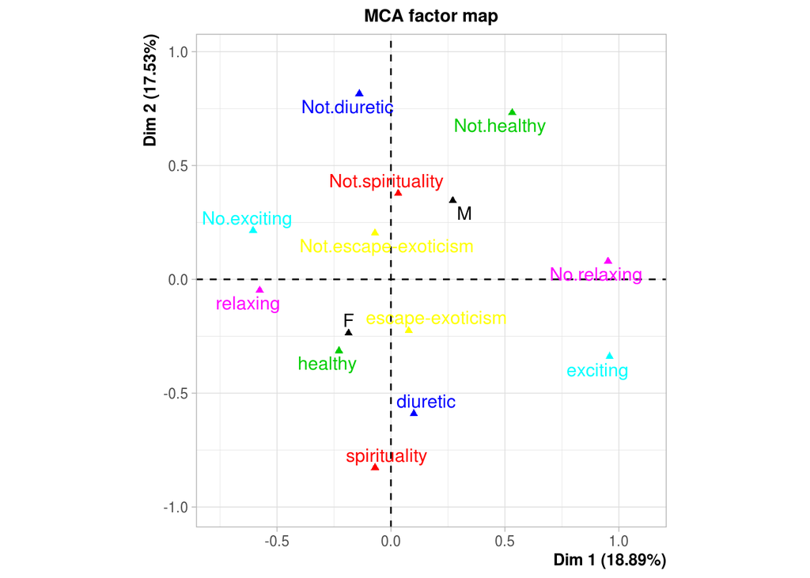

```r
plot(mca, invisible=c("ind"), habillage = "quali")
```

```r
desc_dim <- dimdesc(mca, axes = c(1,2))
# Description of dimension 1
desc_dim[[1]]
```

```
## $quali
##                  R2      p.value
## exciting 0.58019625 4.126097e-58
## relaxing 0.54849837 2.177383e-53
## healthy  0.12134448 5.514632e-10
## sex      0.05048393 8.646168e-05
## diuretic 0.01392559 4.109741e-02
##
## $category
##                          Estimate      p.value
## exciting=exciting      0.33988361 4.126097e-58
## relaxing=No.relaxing   0.33213016 2.177383e-53
## healthy=Not.healthy    0.16518089 5.514632e-10
## sex=M                  0.09939564 8.646168e-05
## diuretic=diuretic      0.05195503 4.109741e-02
## diuretic=Not.diuretic -0.05195503 4.109741e-02
## sex=F                 -0.09939564 8.646168e-05
## healthy=healthy       -0.16518089 5.514632e-10
## relaxing=relaxing     -0.33213016 2.177383e-53
## exciting=No.exciting  -0.33988361 4.126097e-58
##
## attr(,"class")
## [1] "condes" "list "
```

```r
# Description of dimension 2
desc_dim[[2]]
```

```
## $quali
##                          R2      p.value
## diuretic         0.48155717 2.051296e-44
## spirituality     0.31181525 5.400472e-26
## healthy          0.22959277 1.260640e-18
## sex              0.08167713 4.783524e-07
## exciting         0.07269802 2.151942e-06
## escape.exoticism 0.04581619 1.874833e-04
##
## $category
##                                          Estimate      p.value
## diuretic=Not.diuretic                  0.29432081 2.051296e-44
## spirituality=Not.spirituality          0.25200437 5.400472e-26
## healthy=Not.healthy                    0.21887953 1.260640e-18
## sex=M                                  0.12179157 4.783524e-07
## exciting=No.exciting                   0.11589917 2.151942e-06
## escape.exoticism=Not.escape-exoticism  0.08974158 1.874833e-04
## escape.exoticism=escape-exoticism     -0.08974158 1.874833e-04
## exciting=exciting                     -0.11589917 2.151942e-06
## sex=F                                 -0.12179157 4.783524e-07
## healthy=healthy                       -0.21887953 1.260640e-18
## spirituality=spirituality             -0.25200437 5.400472e-26
## diuretic=diuretic                     -0.29432081 2.051296e-44
##
## attr(,"class")
## [1] "condes" "list "
```

*Not diuretic, exciting* and *spirituality* seem to be highly discriminating attributes, since they are far from the origin.

Other plot with ellipses:

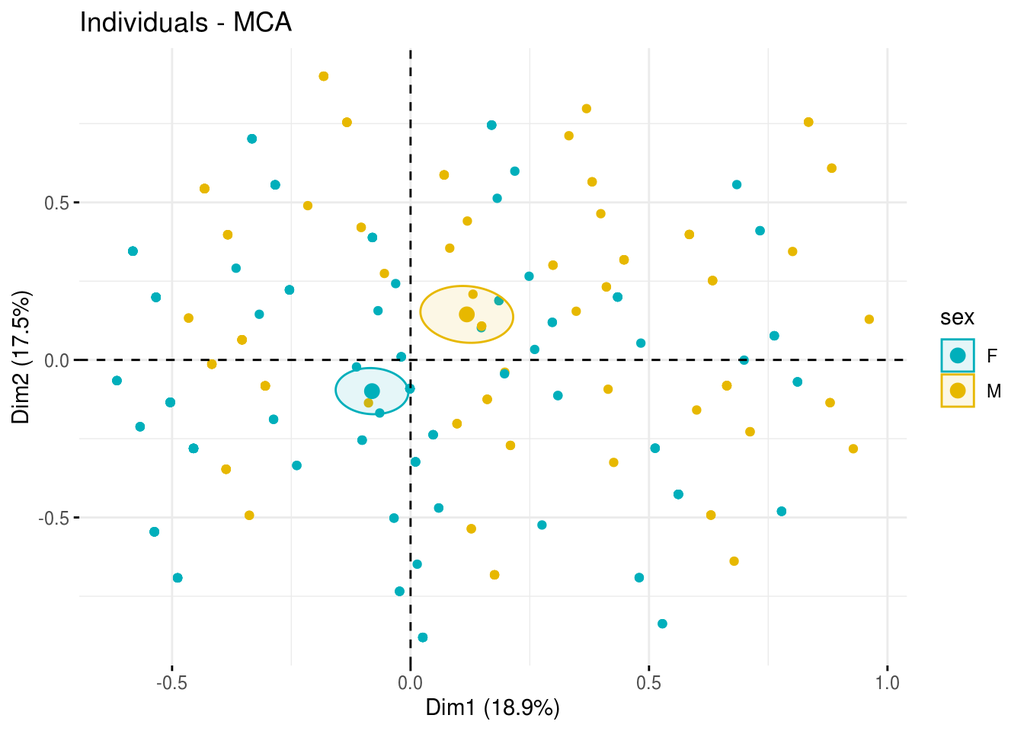

```r
factoextra::fviz_mca_ind(mca,
             label = "none",
             habillage = "sex",
             palette = c("#00AFBB", "#E7B800"),
             addEllipses = TRUE, ellipse.type = "confidence",
             ggtheme = theme_minimal())
```